# StatData1: forel221003

Anders Tolver

# Eksempel med elektriske ål

Formålet med eksemplet er at illustrere

- at der kan være variable i et datasæt, som både kan indgå som faktor (kategorisk variabel) og som kontinuert (kvantitativ variabel) i en statistisk model
- hvordan man kan *teste* om det er rimeligt at lade middelværdien være en lineær funktion af den forklarende variabel (som fx. i en lineær regressionsmodel)

## Indlæsning og visualisering af data

Datasættet `eels` ligger i `isdals` R-pakken

```r
library(isdals)
data(eels)
head(eels)
```

```
##   temp freq
## 1   20  230
## 2   20  239
## 3   20  251
## 4   22  256
## 5   22  259
## 6   22  265
```

Data består af sammenhørende værdier af vandtemperatur (`temp`) og frekvensen (`freq`) af de elektriske signaler, som ålen udsender.

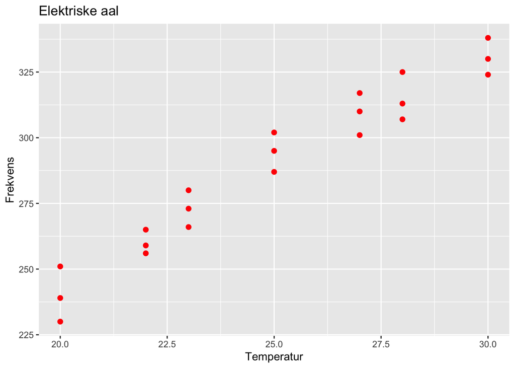

```r
ggplot(data = eels) + geom_point(aes(x = temp, y = freq), color = "red", size = 2) + labs(x = "Temperatur", y = "Frekvens", title = "Elektriske aal")
```

## Lineær regression og ensidet ANOVA

Responsvariablen er den kvantitative variabel `freq` der indholder målinger af frekvensen af de elektriske signaler, som ålen udsender.

Vi ønsker at forklare variationen i frekvensen vha. vandtemperaturen (`temp`), der også er en kvantitativ variable.

Plottet ovenfor lægger op til, at vi kan benytte en lineær regressionsmodel, som fittes nedenfor …

```r
linreg <- lm(freq ~ temp, data=eels)
summary(linreg)$coefficients
```

```
##              Estimate Std. Error   t value     Pr(>|t|)
## (Intercept) 61.649749 12.6430867  4.876163 1.048924e-04
## temp         9.092105  0.5013873 18.133896 1.874721e-13
```

**Bemærk:** **Eftersom der er gentagelser for hver temperatur** så er det også en mulighed at lave ensidet ANOVA. Vi kan også tænke på data som om, at vi har foretaget flere målinger for et antal forskellige vandtemperaturer. Vi kan tænke på målingerne som inddelt i grupper efter vandtemperaturen, hvor der både er forskel i målingerne af frekvensen inden for hver gruppe, og hvor der kan være forskelle mellem middelværdien i hver gruppe (det er det vi vil undersøge med analysen!).

Når vi laver ANOVA, skal vi huske at bruge temperaturevariablen om til en kategorisk variabel (faktor).

```r
eels <- transform(eels, tempFac = factor(temp))
ensidet <- lm(freq ~ tempFac, data=eels)
summary(ensidet)$coefficients
```

```
##              Estimate Std. Error   t value     Pr(>|t|)
## (Intercept) 240.00000   4.551295 52.732245 1.662044e-17
## tempFac22    20.00000   6.436503  3.107277 7.719984e-03
## tempFac23    33.00000   6.436503  5.127008 1.538561e-04
## tempFac25    54.66667   6.436503  8.493225 6.778786e-07
## tempFac27    69.33333   6.436503 10.771895 3.691005e-08
## tempFac28    75.00000   6.436503 11.652290 1.362950e-08
## tempFac30    90.66667   6.436503 14.086324 1.165463e-09
```

### Tillægsspørgsmål til output fra ensidet ANOVA

Lad os kigge på et summary af den ensidede variansanalysemodel

```r
summary(ensidet)
```

```
##
## Call:
## lm(formula = freq ~ tempFac, data = eels)
##
## Residuals:
##      Min       1Q   Median       3Q      Max
## -10.0000  -6.6667  -0.6667   7.0000  11.0000
##
## Coefficients:
##             Estimate Std. Error t value Pr(>|t|)
## (Intercept)  240.000      4.551  52.732  < 2e-16 ***
## tempFac22     20.000      6.437   3.107 0.007720 **
## tempFac23     33.000      6.437   5.127 0.000154 ***
## tempFac25     54.667      6.437   8.493 6.78e-07 ***
## tempFac27     69.333      6.437  10.772 3.69e-08 ***
## tempFac28     75.000      6.437  11.652 1.36e-08 ***
## tempFac30     90.667      6.437  14.086 1.17e-09 ***
## ---
## Signif. codes:  0 '***' 0.001 '**' 0.01 '*' 0.05 '.' 0.1 ' ' 1
##
## Residual standard error: 7.883 on 14 degrees of freedom
## Multiple R-squared:  0.9564, Adjusted R-squared:  0.9377
## F-statistic: 51.14 on 6 and 14 DF,  p-value: 1.004e-08
```

- Opskriv på papir (for dig selv) modellen for ensidet ANOVA og gør dig klart hvor mange populationsparametre, der indgår i modellen.

**Svar:** Vi antager at målinger af frekvensen kan skrives som
$$\texttt{freq}_i = \alpha(\texttt{temp}_i) + e_i$$
hvor $\texttt{temp}_i$ er vandtemperaturen og restleddene/fejlene $e_i$ er uafhængige og normalfordelt med middelværdi $0$ og spredning $\sigma.$ Ud over spredningen $\sigma$ er der $7$ ukendte middelværdier $\alpha(\texttt{20}), \alpha(\texttt{22}), \alpha(\texttt{23}), \ldots, \alpha(\texttt{30})$ hørende til hver af de $7$ temperaturer, som optræder i datasættet.$\square$

- Hvad er estimatet for residualspredningen i modellen, og hvad er fortolkningen af denne parameter?

**Svar:** Estimatet for residualspredningen er $\hat \sigma = 7.883$. Denne parameter angiver spredning på målinger af frekvensen taget ved samme vandtemparatur (spredning inden for grupper).$\square$

- Hvilken parameter i modellen estimeres i linjen som R kalder for `(Intercept)`?
  - Hvilken hypotese kan man teste ved brug af værdierne i søjlerne `t value` og `Pr(>|t|)`?
  - Hvad betyder tallet `4.551`, og hvordan er det fremkommet ud fra estimatet for residualspredningen?
  - Brug output til at konstruere et 95 % - konfidensinterval for parameteren der estimeres i linjen som R kalder for `(Intercept)`.

**Svar:** Linjen `(Intercept)` angiver estimatet for middelværdien i reference-gruppen, som R her har valgt svarende til en vandtemperatur på $20$ grader. Denne parameter har vi i modellen ovenfor kaldt $\alpha(\texttt{20}).$ I samme linje findes under `t value` en t-teststørrelse for test af hypotesen $H_0: \alpha(\texttt{20})=0$ samt den tilhørende p-værdi for testet. Hypotesen forkastes (p-værdien er stort set 0), men hypotesen har ingen praktisk relevans: vi har ingen interessere i en hypotese om, at $\alpha(\texttt{20})=0.$

Tallet $4.551$ angiver *standard error* på estimatet for $\alpha(\texttt{20})$ som i praksis blot er udregnet som gennemsnittet med af de 3 målinger hørende til en vandtemperatur på 20 grader. Standard error på estimatet for $\alpha(\texttt{20})$ er derfor spredningen på en enkelt måling (dvs. 7.883) divideret med $\sqrt{3},$ hvilket netop giver de $4.551.$

Et 95 % konfidensinterval for estimatet for $\alpha(\texttt{20})$ kan beregnes ud fra estimatet (240.00), standard error samt en passende t-fraktil som

```r
ki_low <- 240.00 - qt(0.975, 14) * 4.551
ki_low
```

```
## [1] 230.2391
```

```r
ki_up <- 240.00 + qt(0.975, 14) * 4.551
ki_up
```

```
## [1] 249.7609
```

$\square$

- Hvilken parameter i modellen estimeres i linjen som R kalder for `tempFac22`?
  - Hvilken hypotese kan man teste ved brug af værdierne i søjlerne `t value` og `Pr(>|t|)`?
  - (Svært:) Hvad betyder tallet `6.437`, og hvordan er det fremkommet ud fra estimatet for residualspredningen?
  - Brug output til at konstruere et 95 % - konfidensinterval for parameteren der estimeres i linjen som R kalder for `tempFac22`.

**Svar:** Linjen `tempFac22` angiver estimatet for forskellen i middelværdien for gruppen og reference-gruppen . Denne parameter kan vi ud fra modellen omtale som $\alpha(\texttt{22})-\alpha(\texttt{20}).$ I samme linje findes under `t value` en t-teststørrelse for test af hypotesen $H_0: \alpha(\texttt{22})-\alpha(\texttt{20})=0$ samt den tilhørende p-værdi for testet. Hypotesen forkastes (p-værdien er 0.007720), så vi konkluderer, at der er statistisk signifikant forskel på middelværdien af frekvensen for en vandtemperatur på 22 grader og en vandtemperatur på 20 grader.

Tallet $6.437$ angiver *standard error* på estimatet for forskellen $\alpha(\texttt{22})-\alpha(\texttt{20})$ som i praksis estimeres udregnet som forskellige mellem to gruppe-gennemsnittet hver baseret på de 3 relevante målinger hørende til vandtemperaturen på 20 hhv. 22 grader. Standard error på estimatet for $\alpha(\texttt{22})- \alpha(\texttt{20})$ kan vises at være $\sqrt{\frac{2}{3}}\hat \sigma$, hvor $\hat \sigma$ er estimatet på spredningen for en enkelt måling (dvs. 7.883). Dette giver netop en standard error på $6.437$ som anført i `summary` af modellen.

Et 95 % konfidensinterval for estimatet for $\alpha(\texttt{22})-\alpha(\texttt{20})$ kan beregnes ud fra estimatet (20.00), standard error samt en passende t-fraktil som

```r
ki_low <- 20.00 - qt(0.975, 14) * 6.437
ki_low
```

```
## [1] 6.194008
```

```r
ki_up <- 20.00 + qt(0.975, 14) * 6.437
ki_up
```

```
## [1] 33.80599
```

$\square$

Når du har udregnet konfidensintervallerne ovenfor, så kan du sammenligne med resultaterne fra nedenstående output …

```r
confint(ensidet)
```

```
##                  2.5 %    97.5 %
## (Intercept) 230.238443 249.76156
## tempFac22     6.195074  33.80493
## tempFac23    19.195074  46.80493
## tempFac25    40.861741  68.47159
## tempFac27    55.528407  83.13826
## tempFac28    61.195074  88.80493
## tempFac30    76.861741 104.47159
```

- Forklar, hvordan man kan få R til at beregne et 95 % - konfidensinterval for den gennemsnitlige frekvens af de elektriske signaler som ål udsender i vand der har en temperatur på 30 grader.

**Svar:** Den letteste løsning er at genfitte modellen (ensidet ANOVA) uden intercept.

```r
ensidet2 <- lm(freq ~ tempFac - 1, data=eels)
confint(ensidet2)
```

```
##              2.5 %   97.5 %
## tempFac20 230.2384 249.7616
## tempFac22 250.2384 269.7616
## tempFac23 263.2384 282.7616
## tempFac25 284.9051 304.4282
## tempFac27 299.5718 319.0949
## tempFac28 305.2384 324.7616
## tempFac30 320.9051 340.4282
```

Heraf aflæses nu direkte et 95 % konfidensinterval på 320.9051-340.4282 for den gennemsnitlige frekvens af de elektriske signaler som ål udsender i vand der har en temperatur på 30 grader.$\square$

- Forklar, hvad fortolkningen er af de intervaller, som R udregner med følgende kode

```r
new_data <- data.frame(tempFac = c("20", "22", "23"))
predict(ensidet, new_data, interval = "p")
```

```
##   fit      lwr      upr
## 1 240 220.4769 259.5231
## 2 260 240.4769 279.5231
## 3 273 253.4769 292.5231
```

- Forklar/diskuter, hvorfor følgende R kode vil give en fejl

```r
new_data <- data.frame(tempFac = c("20", "22", "24"))
predict(ensidet, new_data, interval = "p")
```

**Svar:** R-koden fører til en fejl, fordi vi forsøger at lave et prædiktionsinterval hørende til vandtemperaturen 24 grader. Der er ikke lavet nogle målinger for denne vandtemperatur. For en ensidet variansanalysemodel (ANOVA) er der ikke nogen metode til at udvide / interpolere resultater til temperaturer, som ikke er afprøvet i forsøget.

Hvis vi havde benyttet en lineær (eller en kvadratisk) regressionsmodel, så ville vi uden problemer kunne brug den matematiske form af middelværdistrukturen til at komme med prædiktionsintervaller for andre vandtemperaturer end dem i datasættet/stikprøven. **Prøv selv at gøre dette!**$\square$

## Modelkontrol

Som vi lærte i sidste uge, så foretages modelkontrol primært ved at se på residualplot og QQ-plot.

### For lineær regressionsmodel

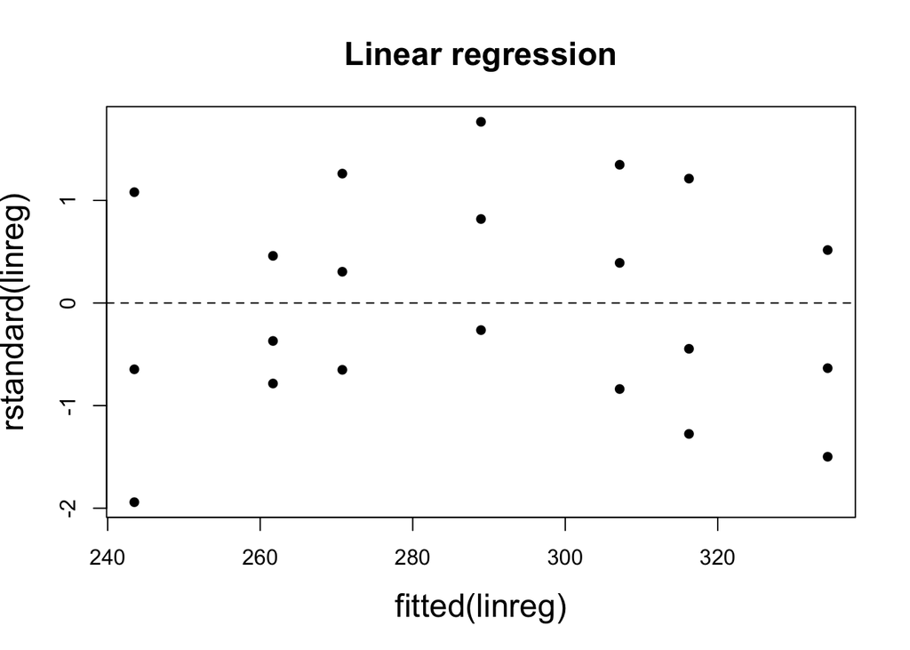

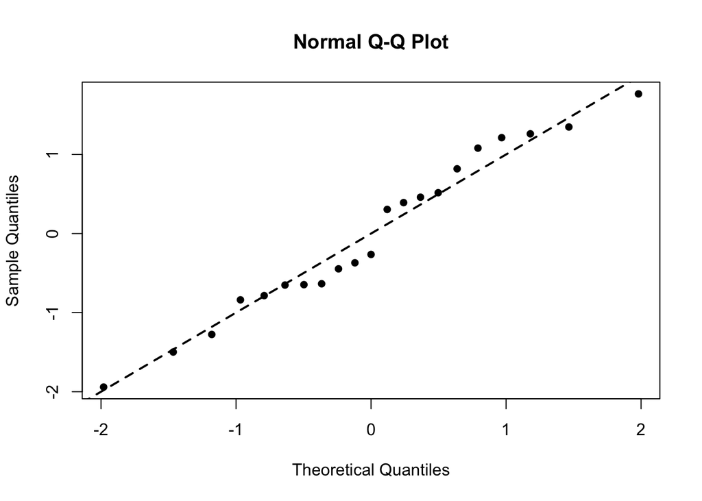

```r
plot(fitted(linreg), rstandard(linreg), pch = 16, main = "Linear regression", cex.main = 1.5, cex.lab = 1.5)
abline(h = 0, lty = 2)
qqnorm(rstandard(linreg), pch = 16)
abline(0, 1, lwd = 2, lty = 2)
```

**Konklusion:**

- Der ses et svag mønster på residualplottet, som kan tyde på, at den lineære struktur af middelværdien ikke passer helt godt på data. Residualerne ligger ikke lige godt omkring 0 for alle fittede værdier.
- Spredningen på residualplottet ser ud til at være ens for alle fittede værdier.
- Punkterne på QQ-plottet afviger ikke systematisk fra den rette linje, så antagelsen om at residualerne/fejlene er normalfordelte virker rimelige.

### For ensidet ANOVA

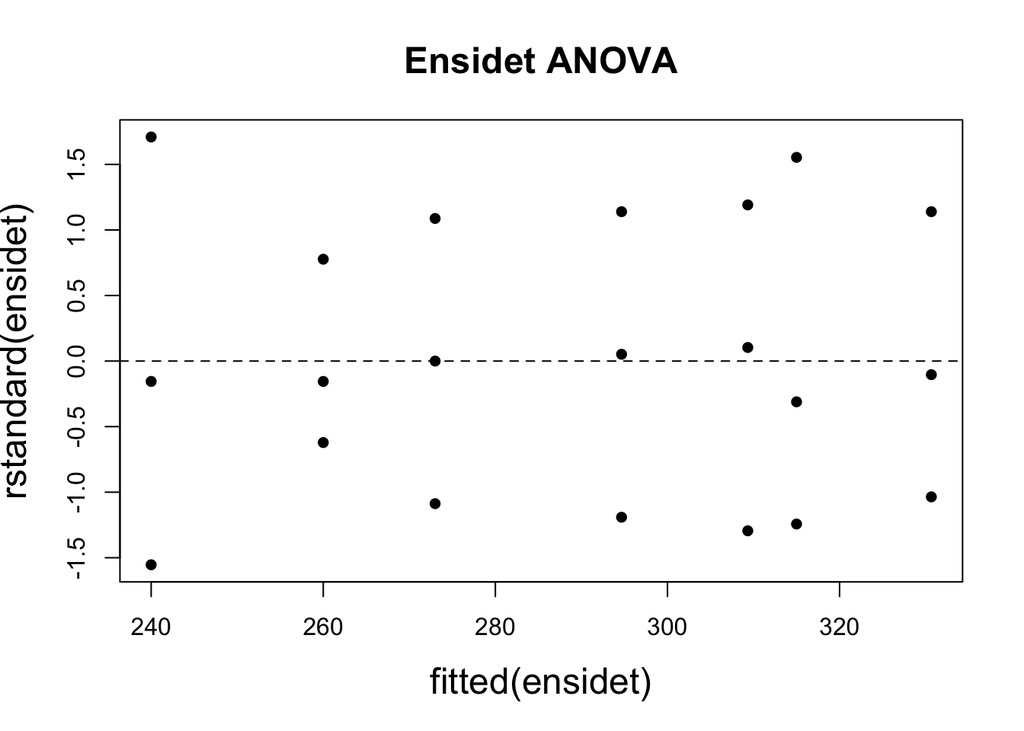

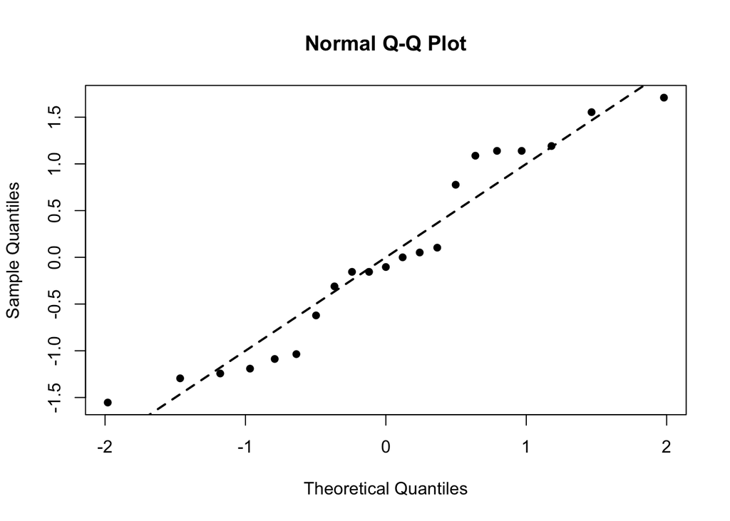

```r
plot(fitted(ensidet), rstandard(ensidet), pch = 16, main = "Ensidet ANOVA", cex.main = 1.5, cex.lab = 1.5)
abline(h = 0, lty = 2)
qqnorm(rstandard(ensidet), pch = 16)
abline(0, 1, lwd = 2, lty = 2)
```

**Konklusion:**

- Residualerne ligger pænt omkring 0 for alle fittede værdier.
- Spredningen på residualplottet ser ud til at være ens for alle fittede værdier.
- Punkterne på QQ-plottet afviger ikke systematisk fra den rette linje, så antagelsen om at residualerne/fejlene er normalfordelte virker rimelige.

## Test for linearitet

### … mod den ensidet ANOVA

Den ensidede ANOVA estimerer et gruppegennemsnit, for hver at de grupper (her: temperaturer) der optræder i datasættet. Middelværdien af responsen (her: frekvensen `freq`) for en observation er (populations)gennemsnittet for den gruppe (dvs. tempereatur), som hører til observationen. Men der er ikkke nogen restriktioner på, hvordan gruppegennemsnittene svarende til forskellige temperatur-grupper skal høre sammen, når vi blot laver en ensidet variansanalyse (ANOVA).

Når vi laver en lineær regressionsmodel, så laver vi en meget kraftig antagelse om, at den den forventede værdi af responsen (her: frekvensen `freq`) skal være en lineær funktion af temperaturen. Specielt skal den forventede værdi af `freq` for temperaturerne 22 og 23 grader ligge lige så tæt på hinanden som den forventede værdi for temperaturerne 27 og 28. I modsætning til for den ensidede ANOVA, så er der altså en *restriktion på* hvordan de forventede værdier (også kaldet middelværdierne) for de forskellige temperaturer skal hænge sammen.

Da den lineære regressionsmodel kan opfattes som en ensidet ANOVA, hvor man har lagt yderligere restriktioner på middelværdier/gruppegennemsnit, så kan vi bruge et F-test (jf. forelæsning og R-program til 26/9-2022) til at **teste** om **den lineære regressionsmodel** giver en fornuftig beskrivelse af data. Hvis vi forkaster hypotesen, så er konklusionen at linearitetsantagelsen i den lineære regressionsmodel ikke er i overensstemmelse med de observerede data.

```r
anova(linreg, ensidet)
```

```
## Analysis of Variance Table
##
## Model 1: freq ~ temp
## Model 2: freq ~ tempFac
##   Res.Df  RSS Df Sum of Sq      F Pr(>F)
## 1     19 1089
## 2     14  870  5    219.02 0.7049 0.6292
```

**Konklusion:**

- F-teststørrelsen for sammenligning af nulmodellen (lineær regression) mod den fulde model (ensidet ANOVA) beregnes til 0.7049.
- Under nulmodellen vil F-teststørrelsen være F-fordelt med (k - 2, n - k)-frihedsgrader, hvor
  - `n = 21`: er antallet af observationer
  - `k = 7`: er antallaet af parametre under den fulde model (her er det blot antal grupper i den ensidede ANOVA)
  - `2`-tallet optræder fordi der er 2 parametre i nulmodellen (den lineære regressionsmodel har en skæring og en hældning)
- R oversætter F-teststørrelsen til en p-værdi på 0.6292 (men udregn evt. selv følgende i R: `1 - pf(0.7049, 7 - 2, 21 - 7)`)
- Data giver ikke anledning til at forkaste nulhypotesen / linearitetshypotesen.

### … mod en kvadratisk regressionsmodel

Det er også muligt at test hypotese om, at middelværdien af `freq` er en lineær funktion af temperaturen (`temp`) ved at **sammenligne den lineære regressionsmodel med en kvadratisk regressionsmodel**.

En kvadratisk regressionsmodel siger, at middelværdien er givet ved

$$\alpha + \beta \cdot \texttt{temp}_i + \delta \cdot \texttt{temp}_i^2.$$
Den lineære regressionsmodel er et specialtilfælde af den kvadratiske regressionsmodel svarende til at

$$\delta = 0.$$

Vi kan udføre testet for hypotesen på to måder

- 1. som et t-test ved at aflæse ud fra `summary()` af den kvadratiske regressionsmodel i den linje der vedrører estimatet for parameteren $\delta$
- 2. ved at opfatte den kvadratiske regressionsmodel som den *fulde model* og den lineære regressionsmodel som *nulmodellen* og udføre testet som et F-test.

**1. som t-test**

```r
kvreg <- lm(freq ~ temp + I(temp^2), data=eels)
summary(kvreg)
```

```
##
## Call:
## lm(formula = freq ~ temp + I(temp^2), data = eels)
##
## Residuals:
##     Min      1Q  Median      3Q     Max
## -9.7970 -6.0849 -0.0849  7.1334 11.8361
##
## Coefficients:
##              Estimate Std. Error t value Pr(>|t|)
## (Intercept) -126.2886   102.3259  -1.234  0.23301
## temp          24.3930     8.2877   2.943  0.00869 **
## I(temp^2)     -0.3060     0.1655  -1.849  0.08092 .
## ---
## Signif. codes:  0 '***' 0.001 '**' 0.01 '*' 0.05 '.' 0.1 ' ' 1
##
## Residual standard error: 7.13 on 18 degrees of freedom
## Multiple R-squared:  0.9541, Adjusted R-squared:  0.949
## F-statistic: 187.1 on 2 and 18 DF,  p-value: 9.048e-13
```

Vi aflæser, at

- estimatet for det kvadratiske led bliver: $\hat{\delta} = -0.3060$
- at t-teststørrelsen for test af hypotesen $\delta = 0$ bliver: -1.849
- at p-værdien ved opslag i en t-fordeling med $18$ frihedsgrader (`degrees of freedom`) bliver: 0.08092

På et 5 % signifikansniveau vil man derfor ikke forkaste nulhypotesen. Linearitetsantagelsen virker altså rimelig i forhold til fx. en antagelse om, at sammenhængen bør modelleres ved en kvadratisk funktion (dvs. et 2.gradspolynomium).

**2. som F-test**

```r
anova(linreg, kvreg)
```

```
## Analysis of Variance Table
##
## Model 1: freq ~ temp
## Model 2: freq ~ temp + I(temp^2)
##   Res.Df     RSS Df Sum of Sq      F  Pr(>F)
## 1     19 1089.02
## 2     18  915.16  1    173.86 3.4196 0.08092 .
## ---
## Signif. codes:  0 '***' 0.001 '**' 0.01 '*' 0.05 '.' 0.1 ' ' 1
```

- F-teststørrelsen for sammenligning af nulmodellen (lineær regression) mod den fulde model (kvadratisk ANOVA) beregnes til 3.4196.
- Under nulmodellen vil F-teststørrelsen være F-fordelt med (k - 2, n - k)-frihedsgrader, hvor
  - `n = 21`: er antallet af observationer
  - `k = 3`: er antallaet af parametre under den fulde model (her er det de tre parametre i den kvadratiske regressionsmodel)
  - `2`-tallet optræder fordi der er 2 parametre i nulmodellen (den lineære regressionsmodel har en skæring og en hældning)
- R oversætter F-teststørrelsen til en p-værdi på 0.08092 (men udregn evt. selv følgende i R: `1 - pf(3.4196, 3 - 2, 21 - 3)`)
- Data giver ikke anledning til at forkaste nulhypotesen / linearitetshypotesen.